# Summarise UPC Data OCNMS July 2020

Genoa Sullaway

July 2020

## Approach

This uses 2016-2019 data, 2015 UPC uses quadrats and is inconsistent with later methods, calculates mean and standard deviation (specific to beta distributed data) for a few different flavors of data summaries, below.

All data sets are saved in: OCNMS/Data/Summarized data

There are three **percent cover** data sets:

1. dat.transect.summary = UPC_Transect_Level_Summary.csv: This has percent cover across TRANSECT/ZONE/SIDE/SITE/YEAR. Transect is lowest level of replication here. There are only 11 transects in whole dataset that have less than 30 upc counts (aka an incomplete transect)… In the cases where it is less than 30 I get total % cover from the total points sampled for that transect.

2. dat.zone.summary = UPC_Zone_Level_Summary.csv: This has mean percent cover and variance across ZONE/SITE/YEAR.

3. dat.site.summary = UPC_Site_Level_Summary.csv: This has mean percent cover and variance across SITES.

There are four **Simspons Diversity** data sets:

1. dat.diversity = UPC_DIVERSITY_Transect_Level_Summary.csv: This has Simpsons Diversity across TRANSECT/ZONE/SIDE/SITE/YEAR. Transect is lowest level of replication here.

2. dat.diversity.zone.summary = UPC_DIVERSITY_Zone_Level_Summary.csv: This has mean Simpsons Diversity and variance across ZONE/SITE/YEAR.

3. dat.diversity.year.site.summary= UPC_DIVERSITY_Year_Site_Level_Summary.csv: This has mean Simpsons Diversity and variance across SITE/YEAR.

4. dat.diversity.site.summary = UPC_DIVERSITY_Site_Level_Summary.csv: This has Simpsons Diversity and variance across SITES.

## Summary Thoughts

- Two northern sites, Neah Bay and Tattoosh, appear to have more diversity in percent cover per transect than the three southern sites. There dont appear to be huge differences among years or zones, biggest differences are among Sites. This is reflected in Simpsons Index and in the stacked bar plots using percent cover.

```r
#to load data make sure directory is set to knit from project directory
knitr::opts_chunk$set(message=FALSE, warning=FALSE)

library(here)
library(tidyverse)
library(knitr)
library(viridis)

substrate_codes <- read_csv(here("Data","CSV_2015_on","substrate_codes.csv"))

#2016 --> 2019
dat.upc <- read_csv(here("Data","CSV_2015_on","NWFSC_UPC_ALLYEARS_data_2019.csv"), col_types = cols(SIDE = col_character())) %>%
              filter(CATEGORY == "COVER") %>%
              select(1:20) %>%
              rename(DEPTH.FT= "DEPTH (FT)")  %>%
              #mutate(QUADRAT = NA, PERCENT.COVER = NA) %>% #will circle back tothis and get % cover for 2016 to 2019 data
              select(SITE, MONTH, DAY, YEAR, OBSERVER, TRANSECT , CLASSCODE, COUNT,DEPTH.FT,SIDE,ZONE,TRANSECT,BUDDY,SEGMENT) %>%
#dat.upc <- rbind(dat.2015, dat.2016) %>%
 mutate(COUNT = replace_na(COUNT, 0)) %>%
 left_join(substrate_codes) %>% #rename two that arent in substrate key
 mutate(NAME = case_when(CLASSCODE == "ptero" | NAME == "Pterogophora" ~ "Pterygophora",
                          CLASSCODE == "shell" ~ "various bivalves",
                          TRUE ~ NAME),
#ASSIGN FUNCTIONAL GROUPS
         Functional_Group = case_when(
                                    NAME %in% c("Red algae (branching flat blade)", "Red algae (cylindrical branches)", "Red algae (lacy branching)", "Red algae (leaf-like)") ~ "Red Algae",
                                    NAME %in% c("articulated coralline","Encrusting hydrocoral (eg. Stylantheca)","Red algae -Encrusting", "Coralline algae -Crustose") ~ "Encrusting Species",
                                    NAME %in% c("Pterygophora", "Brown algae understory prone","Nereocystis holdfast (alive)", "Macrosystis holdfast (alive)", "Laminariales holdfast (alive)") ~ "Brown Algae",
                                    NAME %in% c("Anemone", "Bryozoan", "Cup Coral","Tunicate -Colonial,compund,social","Tunicate -Solitary", "Hydroid", "Sponge", "Barnacle","Tubeworm") ~ "Non-mobile Invertebrate",
                                     NAME %in% c("various bivalves", "Scallop","urchin", "Cucumaria spp.' sea cucumber") ~ "Mobile Invertebrate",
                                    NAME %in% c("Substrate: Bedrock","Shell Debris","Bare Sand", "Substrate: Cobble","Sediment/Mud", "Substrate: Sand","Bare Rock" ) ~ "Non-living Substrate",
                                    NAME %in% c("Zostera marina, eelgrass" , "Phyllospadix spp.' surfgrass") ~ "Eelgrass_Surfgrass",
                                    TRUE ~ NAME),
 #ASSIGN ORGANISM GROUPS
        Organism_Group = case_when(NAME %in% c("Red algae (branching flat blade)", "Red algae (cylindrical branches", "Red algae (lacy branching)","Pterygophora", "Brown algae understory prone","Red algae -Encrusting", "Coralline algae -Crustose","Nereocystis holdfast (alive)","Macrosystis holdfast (alive)","Phyllospadix spp.' surfgrass", "Zostera marina, eelgrass","Encrusting hydrocoral (eg. Stylantheca)","Green algae","Laminariales holdfast (alive)","articulated coralline", "Red algae (cylindrical branches)","Red algae (leaf-like)") ~ "Plant_Algae",
                                    NAME %in% c("various bivalves", "Scallop","Anemone", "Cup Coral","Barnacle","Tunicate -Colonial,compund,social", "Tunicate -Solitary","urchin","Bryozoan","Diatom Layer","Sponge","Tubeworm","Hydroid", "Cucumaria spp.' sea cucumber") ~ "Invertebrate",
                                    NAME %in% c("Substrate: Bedrock","Shell Debris","Bare Sand", "Substrate: Cobble","Sediment/Mud", "Substrate: Sand","Bare Rock" ) ~ "Non-living Substrate",
                                    TRUE ~ NAME))
```

| Organism_Group | Functional_Group | NAME | species_occurence |
| --- | --- | --- | --- |
| Invertebrate | Diatom Layer | Diatom Layer | 39 |
| Invertebrate | Mobile Invertebrate | Cucumaria spp.’ sea cucumber | 2 |
| Invertebrate | Mobile Invertebrate | Scallop | 1 |
| Invertebrate | Mobile Invertebrate | urchin | 1 |
| Invertebrate | Mobile Invertebrate | various bivalves | 4 |
| Invertebrate | Non-mobile Invertebrate | Anemone | 4 |
| Invertebrate | Non-mobile Invertebrate | Barnacle | 185 |
| Invertebrate | Non-mobile Invertebrate | Bryozoan | 96 |
| Invertebrate | Non-mobile Invertebrate | Cup Coral | 20 |
| Invertebrate | Non-mobile Invertebrate | Hydroid | 52 |
| Invertebrate | Non-mobile Invertebrate | Sponge | 128 |
| Invertebrate | Non-mobile Invertebrate | Tubeworm | 24 |
| Invertebrate | Non-mobile Invertebrate | Tunicate -Colonial,compund,social | 161 |
| Invertebrate | Non-mobile Invertebrate | Tunicate -Solitary | 1 |
| Non-living Substrate | Non-living Substrate | Bare Rock | 160 |
| Non-living Substrate | Non-living Substrate | Bare Sand | 97 |
| Non-living Substrate | Non-living Substrate | Shell Debris | 244 |
| Non-living Substrate | Non-living Substrate | Substrate: Sand | 73 |
| Plant_Algae | Brown Algae | Brown algae understory prone | 944 |
| Plant_Algae | Brown Algae | Laminariales holdfast (alive) | 10 |
| Plant_Algae | Brown Algae | Macrosystis holdfast (alive) | 87 |
| Plant_Algae | Brown Algae | Nereocystis holdfast (alive) | 74 |
| Plant_Algae | Brown Algae | Pterygophora | 333 |
| Plant_Algae | Eelgrass_Surfgrass | Phyllospadix spp.’ surfgrass | 42 |
| Plant_Algae | Eelgrass_Surfgrass | Zostera marina, eelgrass | 2 |
| Plant_Algae | Encrusting Species | articulated coralline | 157 |
| Plant_Algae | Encrusting Species | Coralline algae -Crustose | 1062 |
| Plant_Algae | Encrusting Species | Encrusting hydrocoral (eg. Stylantheca) | 1 |
| Plant_Algae | Encrusting Species | Red algae -Encrusting | 155 |
| Plant_Algae | Green algae | Green algae | 3 |
| Plant_Algae | Red Algae | Red algae (branching flat blade) | 2388 |
| Plant_Algae | Red Algae | Red algae (cylindrical branches) | 79 |
| Plant_Algae | Red Algae | Red algae (lacy branching) | 109 |
| Plant_Algae | Red Algae | Red algae (leaf-like) | 1582 |

## Species Occurence and Grouping Plots

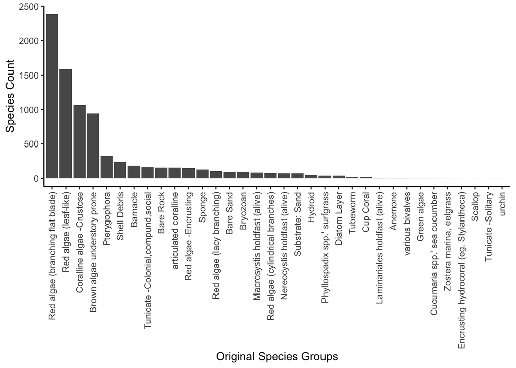

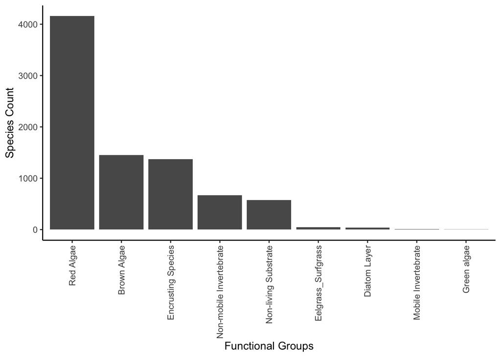

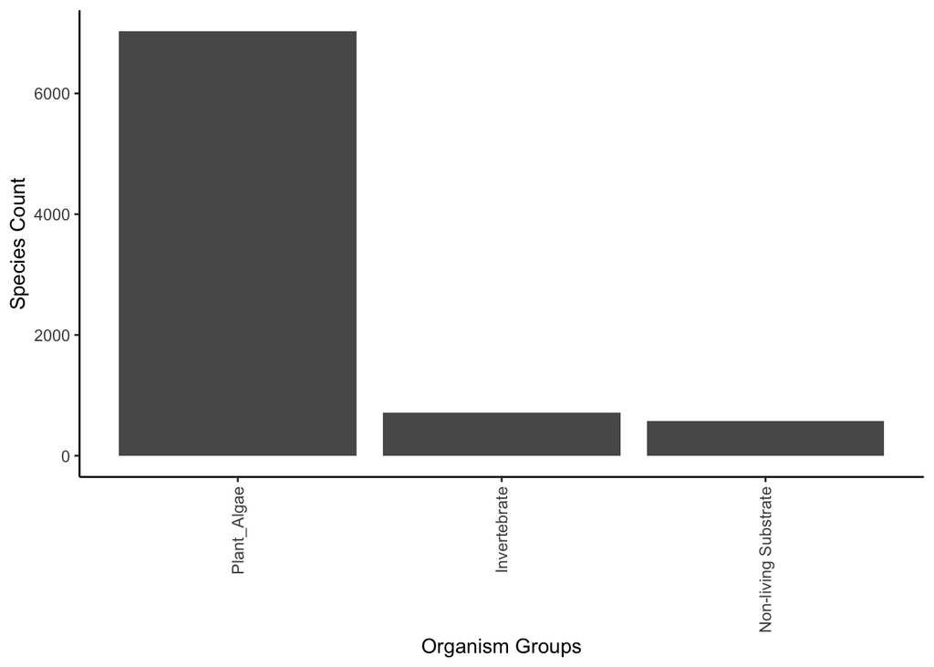

## Percent Cover

### Create data frames

```r
dat.transect.summary <- dat.upc %>%
  filter(YEAR > 2015) %>%
  group_by(YEAR,SITE,SIDE,ZONE,TRANSECT,DEPTH.FT,Functional_Group) %>%
  summarise(COUNT = sum(COUNT)) %>%
  spread(Functional_Group, COUNT) %>%
  ungroup() %>%
  replace(is.na(.), 0) %>%
  dplyr::mutate(Sum = rowSums(.[,7:15])) %>%
  tidyr::gather(7:15, key = "Functional_Group", value = "COUNT") %>%
  mutate(percent_cover = COUNT/Sum)

dat.zone.summary <- dat.transect.summary %>%
  group_by(YEAR,SITE,ZONE,Functional_Group) %>%
 summarise(
      N=length(percent_cover),
      MEAN=mean(percent_cover),
      SD=sqrt(MEAN * (1 - MEAN) * N),
      SE=SD/sqrt(N)) %>%
  ungroup() %>%
  mutate(SITE = factor(SITE, levels = c("Destruction Island","Cape Johnson", "Cape Alava","Tatoosh Island","Neah Bay")))

dat.site.summary <- dat.transect.summary %>%
  group_by(SITE,Functional_Group) %>%
  summarise(
      N=length(percent_cover),
      MEAN=mean(percent_cover),
      SD=sqrt(MEAN * (1 - MEAN) * N),
      SE=SD/sqrt(N)) %>%
  ungroup() %>%
  mutate(SITE = factor(SITE, levels = c("Destruction Island","Cape Johnson", "Cape Alava","Tatoosh Island","Neah Bay")))

  write.csv(dat.transect.summary, here("Data","Summarized data","UPC_Transect_Level_Summary.csv"))
  write.csv(dat.zone.summary, here("Data","Summarized data","UPC_Zone_Level_Summary.csv"))
  write.csv(dat.site.summary, here("Data","Summarized data","UPC_Site_Level_Summary.csv"))
```

### Plots

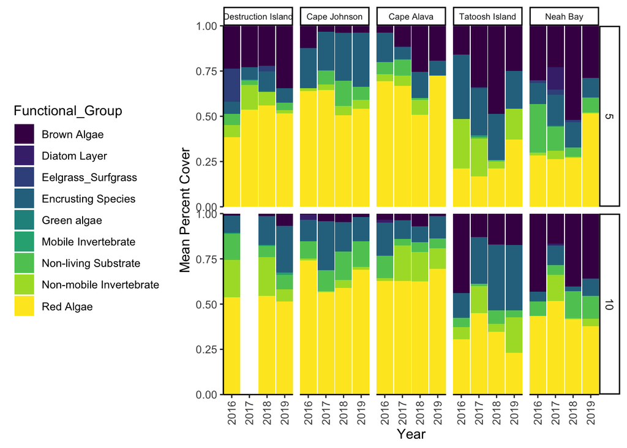

Also see what it looks like if I lump across years and zones, largest differences across zones seem to be increased brown algae in 5m zone and sligthly higher functional group richness in shallower areas.

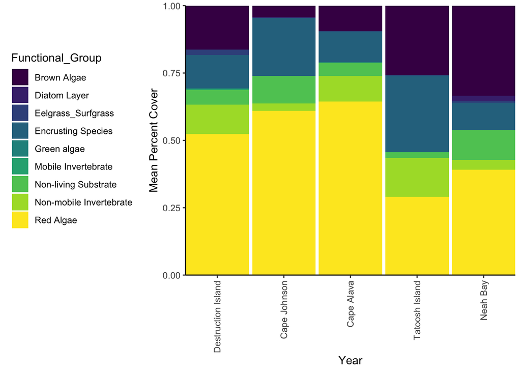

## Simpsons Diversity Index

### Create data frames

```r
#use dat.relief to get Simpsons index for every transect and save data frames
dat.diversity<- dat.transect.summary %>%
    group_by(YEAR,SITE,ZONE,SIDE,TRANSECT,Functional_Group) %>%
    dplyr::summarise(
            PROPORTION=sum(percent_cover),
            PROPORTION_2=sum(PROPORTION)^2,
             .groups = "keep") %>%
      group_by(YEAR,SITE,ZONE,SIDE,TRANSECT) %>%
    dplyr::summarise(
            DIVERSITY= sum(PROPORTION_2),
            RELIEF_SIMPSONS_DIVERSITY= 1 - DIVERSITY, # simpsons diversity
            .groups = "keep"
    ) %>%
    select(-DIVERSITY)

# calculate substrate diversity for each site-year-zone
  dat.diversity.zone.summary <- dat.diversity %>%
    group_by(YEAR,SITE,ZONE) %>%
    dplyr::summarise(
      MEAN=mean(RELIEF_SIMPSONS_DIVERSITY),
      SD= sd(RELIEF_SIMPSONS_DIVERSITY),
      N=length(RELIEF_SIMPSONS_DIVERSITY),
      SE=SD/sqrt(N),
      .groups = "keep"
      )

# calculate substrate diversity for each site
  dat.diversity.year.site.summary <- dat.diversity %>%
    group_by(YEAR,SITE) %>%
    dplyr::summarise(
      MEAN=mean(RELIEF_SIMPSONS_DIVERSITY),
      SD= sd(RELIEF_SIMPSONS_DIVERSITY),
      N=length(RELIEF_SIMPSONS_DIVERSITY),
      SE=SD/sqrt(N),
      .groups = "keep"
      )

  # calculate substrate diversity for each site
  dat.diversity.site.summary <- dat.diversity %>%
    group_by(SITE) %>%
    dplyr::summarise(
      MEAN=mean(RELIEF_SIMPSONS_DIVERSITY),
      SD= sd(RELIEF_SIMPSONS_DIVERSITY),
      N=length(RELIEF_SIMPSONS_DIVERSITY),
      SE=SD/sqrt(N),
      .groups = "keep"
      )

  write.csv(dat.diversity, here("Data","Summarized data","UPC_DIVERSITY_Transect_Level_Summary.csv"))
  write.csv(dat.diversity.zone.summary, here("Data","Summarized data","UPC_DIVERSITY_Zone_Level_Summary.csv"))
  write.csv(dat.diversity.site.summary, here("Data","Summarized data","UPC_DIVERSITY_Site_Level_Summary.csv"))
  write.csv(dat.diversity.year.site.summary, here("Data","Summarized data","UPC_DIVERSITY_Year_Site_Level_Summary.csv"))
```

### Plots

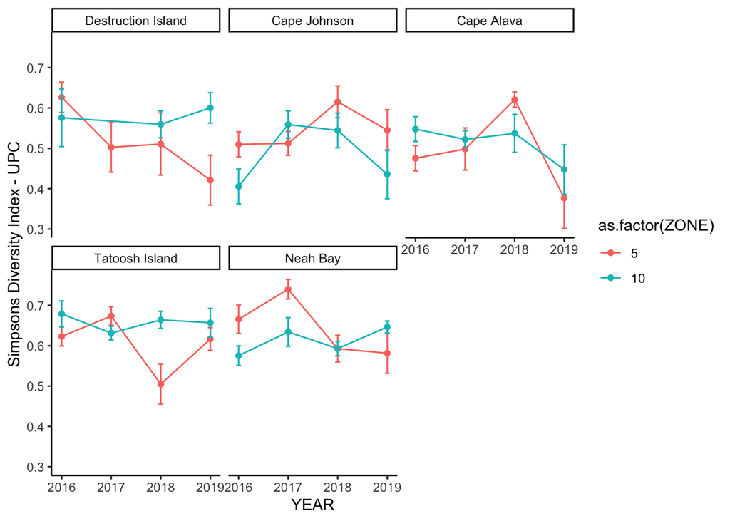

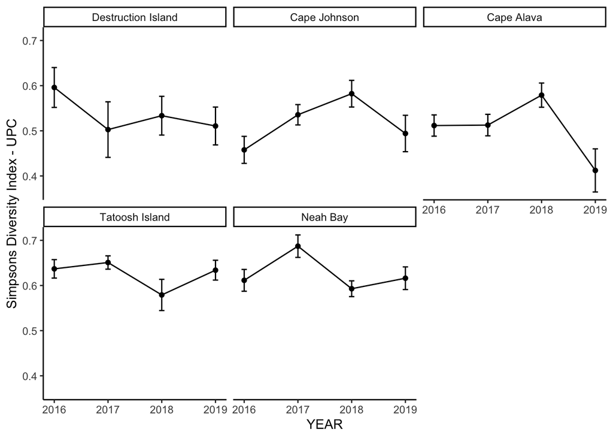

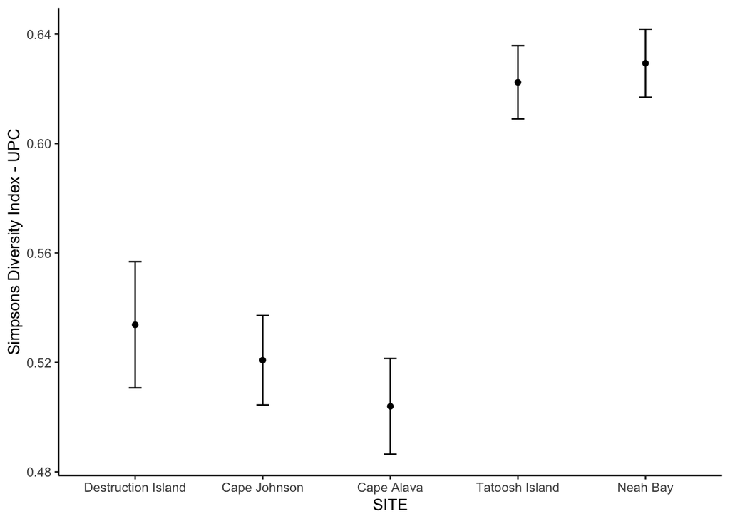